# 1. foreach

# The package `foreach`

## The foreach looping construct

The package [foreach](https://cran.r-project.org/web/packages/foreach/vignettes/foreach.html) introduces a looping construct that supports parallel execution

The `foreach` loop looks similar to a `for` loop, but is implemented using a binary operator, called `%do%`. Unlike `for`, it returns a value

```r
library(foreach)
foreach(i=1:5) %do% sprintf("Hello from iteration %s", i)
```

```
[[1]]
[1] "Hello from iteration 1"

[[2]]
[1] "Hello from iteration 2"

[[3]]
[1] "Hello from iteration 3"

[[4]]
[1] "Hello from iteration 4"

[[5]]
[1] "Hello from iteration 5"
```

The loop `foreach` with the operator `%do%` runs locally and single threaded, pretty much like `for`. This is essentially used for intermediate local tests.

`foreach` comes with another operator, `%dopar%` that runs iterations in parallel. In order to do so, we need to register a parallel backend

## Registering a parallel backend

There are multiple packages that implement functionality to create and register parallel backend clusters:

- `foreach::registerDoSEQ` explicitly register the default sequential backend
- `doParallel::registerDoParallel` local cluster via library(parallel)
- `doFuture::registerDoFuture` HPC with schedulers
- `future::makeClusterMPI` Message Passing Interface (MPI) cluster
- `doAzureParallel::registerDoAzureParallel`

Example: local cluster with `doParallel`:

```r
library(doParallel)
local_cluster <- parallel::makeCluster(4)
registerDoParallel(local_cluster)

n <- 100000
iterations <- 4
start_p <- Sys.time()
closingPrices_p <- foreach(i = seq(iterations), .combine = "c") %dopar% {
    replicate(n/iterations, getClosingPrice())
}
end_p <- Sys.time()
difftime(end_p, start_p)
```

```
Time difference of 7.530658 secs
```

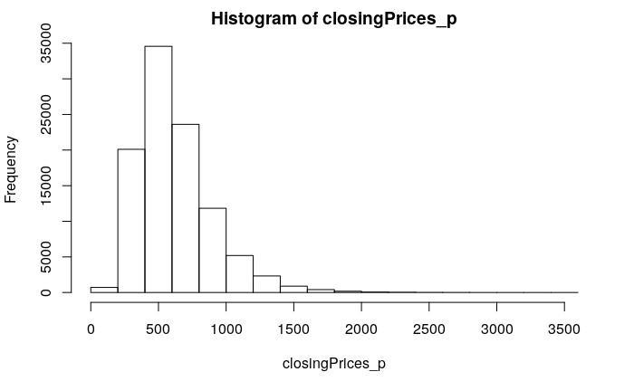

```r
hist(closingPrices_p)
```

## Combining results

`foreach` returns a combination of the result of each iteration. By default, the results are combined into a list as long as the number of iterations. This behaviour can be changed using the parameter `.combine`

In the previous example we specify `.combine = "c"`, hence the results are combined into a vector.

We can as well combine the into columns or rows of a matrix:

```r
foreach(i = 1:4, .combine = "cbind") %dopar% rnorm(5)
```

```
executing %dopar% sequentially: no parallel backend registered
```

```
       result.1   result.2   result.3   result.4
[1,]  1.0565175  0.8994284  0.8381176  0.2826302
[2,]  0.4224480  0.9487208 -0.9198726 -1.0868551
[3,]  1.1741496 -0.1737249  1.2104276 -0.4990399
[4,] -0.1452602 -1.0182202 -0.9309285 -0.1001006
[5,] -0.7476172 -0.9819575  0.3657694  1.3312580
```

```r
foreach(i = 1:4, .combine = "rbind") %dopar% rnorm(5)
```

```
               [,1]       [,2]        [,3]       [,4]       [,5]
result.1  1.1871049  1.3398952 -0.25966276  1.3045006 -0.6057909
result.2 -0.3413961 -2.1242218 -0.72700754 -0.3586803 -0.2833126
result.3 -0.7177543  0.1474961  0.66820709  0.1803878 -0.1770831
result.4  1.6157991 -0.5118934 -0.09109324  1.1233686  1.0664885
```